# 02_GEMSx003.0w1_Ex3_AnswerKey

# Introduction to Spatial Data Analysis in R

## Instructors:

Ali Joglekar, University of Minnesota (joglekar@umn.edu)  
Yuan Chai, University of Minnesota (chaix026@umn.edu)

## **Exercise 3: Explore Malawi LSMS Wave 5 (Raster) Data**

> *Data Source:*  
> The data were aggregated from SRTM 90 m resolution data between -60 and 60 latitude.

The data will be downloaded directly using the `geodata::elevation_30s()` function in R

```r
# Spatial data libraries
library(sf)
library(terra)
library(geodata)

# Plotting libraries
library(tmap)
```

1. Using the command `mwi_dem <- elevation_30s(country='MWI', mask=TRUE, path = "./data/MWI")`, download the digital elevation model (dem) data for Malawi.

   ```r
   mwi_dem <- elevation_30s(country='MWI', mask=TRUE, path = "../data/MWI")
   ```

2. Set coordinate reference system using the command `crs(mwi_dem) <- "epsg:4326"`

   ```r
   crs(mwi_dem) <- "epsg:4326"
   ```

3. Explore the characteristics of your raster.
   1. How many rows and columns does it have?
   2. What is the resolution?
   3. What is the coordinate reference system?
   4. What is the distribution of values?

      By printing your raster object `mwi_dem` or using `nrow(mwi_dem)`, `ncol(mwi_dem)`, `res(mwi_dem)`, and `crs(mwi_dem)` you can see that
      - There are 948 rows and 408 columns
      - The cell resolution is 0.008333333 degrees, which is also referred to as 30 arc-seconds (approximately 1km at the equator)
      - The coordinate reference system is lon/lat WGS 84 (EPSG:4326)
      - The distribution of elevation ranges from 32 meters to 2,748 meters above sea level

      The distribution of elevation can also be seen using a histogram

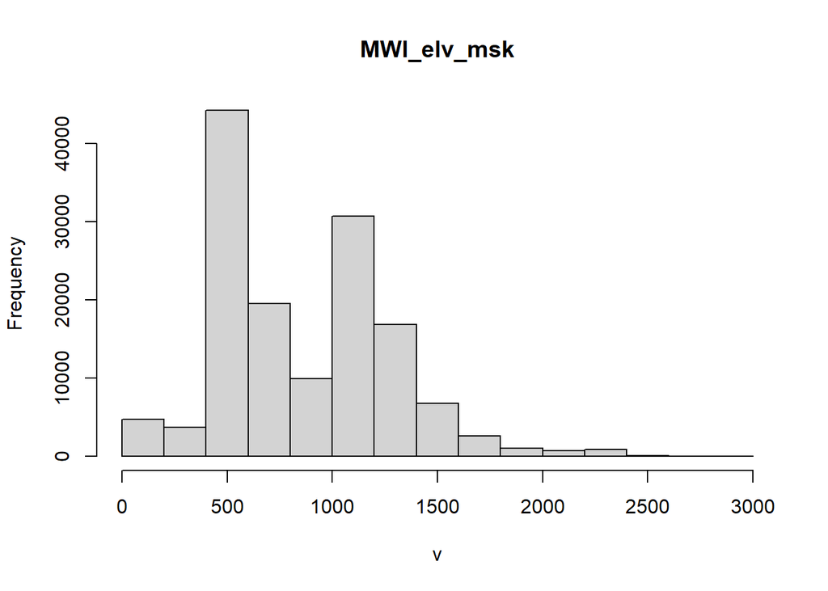

      ```r
      hist(mwi_dem)
      ```

5. Create some maps
   1. Plot a map of elevation in base R.
   2. Plot a map of elevation in tmap.

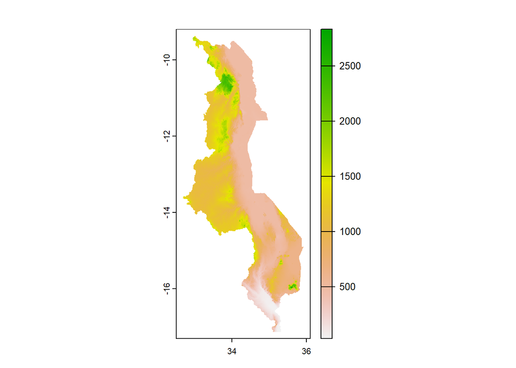

   ```r
   # elevation in base R
   plot(mwi_dem)
   ```

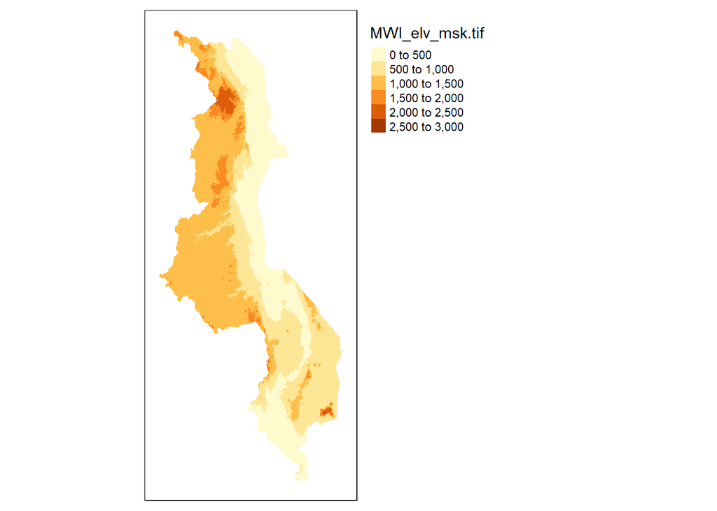

   ```r
   # elevation in tmap
   tm_shape(mwi_dem) +
     tm_raster() +
     tm_layout(legend.outside = TRUE)
   ```